# 2.2 Panel Data | Becoming Fluent in Data

This book is **Work in Progress**. I appreciate your feedback to make the book better.

## 2.2 Panel Data

### 2.2.1 Unemployment

Unemployment occurs when someone is willing and able to work but does not have a paid job. Unemployment is measured by the unemployment rate. The unemployment rate is the most commonly used indicator for understanding conditions in the labour market.

> The personal and social costs of unemployment include severe financial hardship and poverty, debt, homelessness and housing stress, family tensions and breakdown, boredom, alienation, shame and stigma, increased social isolation, crime, erosion of confidence and self-esteem, the atrophying of work skills and ill-health.

#### 2.2.1.1 On decline in Germany

[figure not shown]

Figure 2.1: Unemployment rate in Germany

## Reading

**[How Low Can Unemployment Really Go? Economists Have No Idea](https://www.nytimes.com/2018/02/28/upshot/how-low-can-unemployment-really-go-economists-have-no-idea.html)** "Here are two things most economists can agree upon: They want an economy where everyone who seeks a job can get one. Yet for the economy to be dynamic, some people will always be unemployed, at least temporarily as they move between jobs."

**Life after college.**

[figure not shown]

Panel data allows to analyze the level of unemployment in Germany as well as the changes and trajectories of individuals. We can separate a *frictional unemployment* component and a *permanent unemployment* share. Frictional unemployment is a form of unemployment reflecting the gap between someone voluntarily leaving a job and finding another. As such, it is sometimes called search unemployment. Is search unemployment acceptable? Is it different from long-term unemployment? What do you think.

#### 2.2.1.2 Measurement

The **unemployment rate** represents the proportion of the **civilian labour force** that is unemployed. Consequently, measuring the unemployment rate requires identifying who is in the labour force. The labour force consists of all employed and unemployed persons of working age. What exactly is defined as employment? Employment status can be defined via a threshold of working hours or income. Who is in the working age?

## Reading

In Australia, the Australian Bureau of Statistics (ABS) conducts a survey each month – called the Labour Force Survey – in which it asks around 50,000 people. As part of this survey, the ABS groups people aged 15 years and over (the working-age population) into three broad categories:

- **Employed** – includes people who are in a paid job for one hour or more in a week.
- **Unemployed** – people who are not in a paid job, but who are actively looking for work.
- **Not in the labour force** – people not in a paid job, and who are not looking for work.

Read More: [Unemployment: Its Measurement and Types](https://www.rba.gov.au/education/resources/explainers/unemployment-its-measurement-and-types.html)

### 2.2.2 Application

#### 2.2.2.1 Data Inspection

SOEP practice data (2015 - 2019) comes labeled and ready for analysis. SOEP provides a digital object identifier (DOI) for this data: https://doi.org/10.5684/soep.practice.v36.[^24]

```r
library(haven)
soep <- read_dta("https://github.com/MarcoKuehne/marcokuehne.github.io/blob/main/data/SOEP/practice_en/practice_dataset_eng.dta?raw=true")
```

This practice data contains socio-economic information on children, education, job, health, satisfaction and income. It contains 15 variables and 23522 observations.

Unique

Missing Pct.

Mean

SD

Min

Median

Max

Histogram

syear

5

0

2016.8

1.4

2015.0

2017.0

2019.0

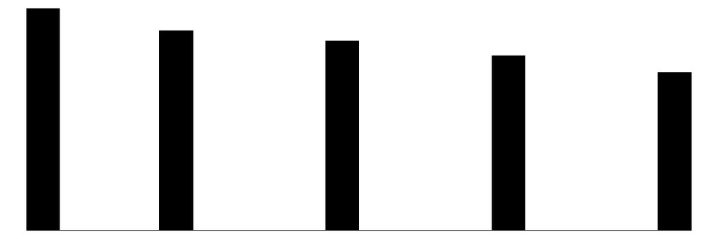

sex

2

0

0.5

0.5

0.0

1.0

1.0

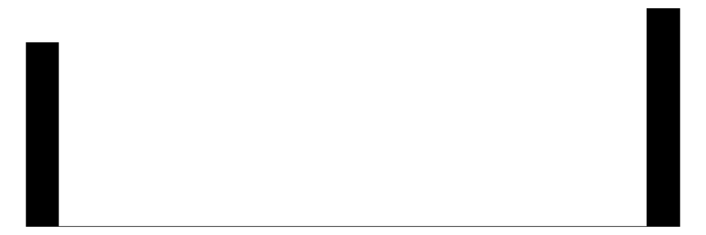

alter

86

0

48.3

18.3

17.0

48.0

102.0

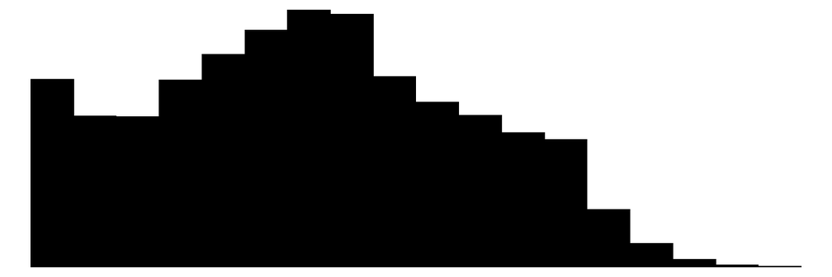

anz_pers

13

0

2.9

1.5

1.0

2.0

13.0

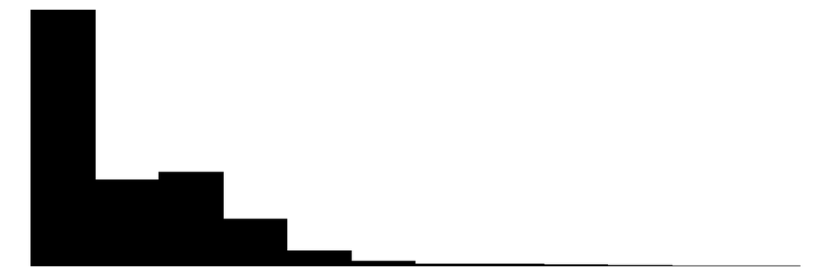

anz_kind

12

0

0.7

1.1

0.0

0.0

10.0

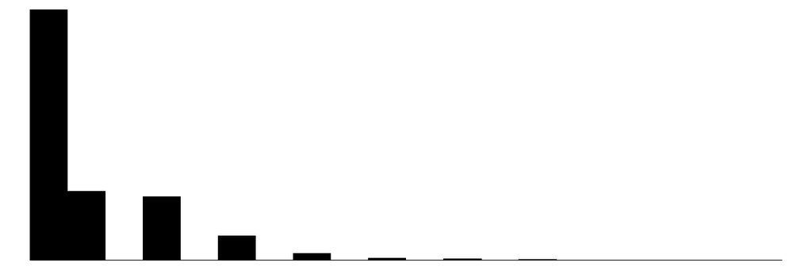

bildung

17

7

12.4

2.8

7.0

11.5

18.0

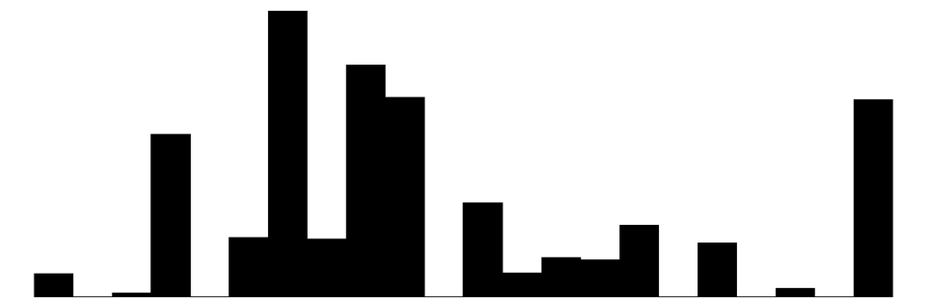

erwerb

7

0

3.0

1.8

1.0

2.0

6.0

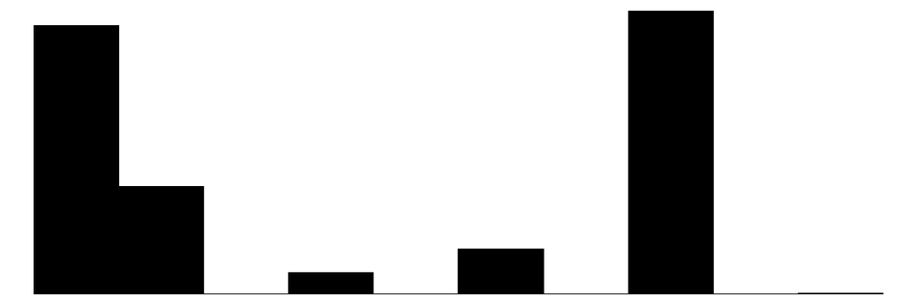

branche

84

42

60.5

25.3

1.0

64.0

99.0

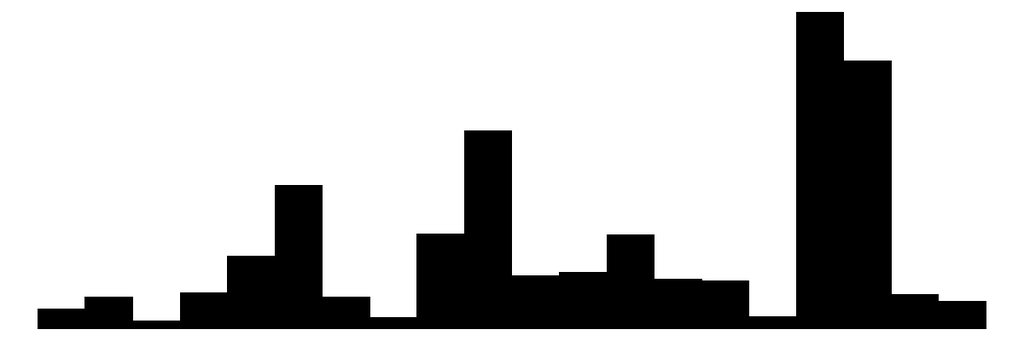

gesund_org

6

0

2.6

1.0

1.0

2.0

5.0

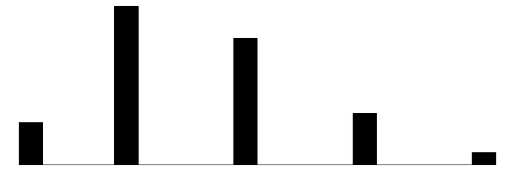

lebensz_org

12

3

7.4

1.7

0.0

8.0

10.0

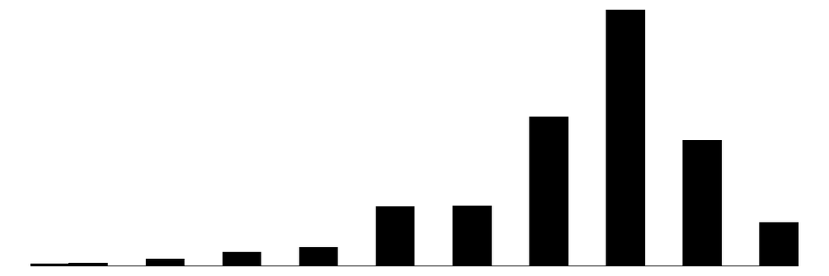

einkommenj1

13346

0

16775.8

22707.6

0.0

5786.1

269424.9

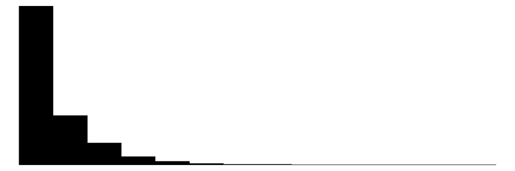

einkommenj2

1871

0

315.7

1887.6

0.0

0.0

79179.9

[figure not shown]

einkommenm1

14067

0

1645.6

2220.6

0.0

852.9

35260.9

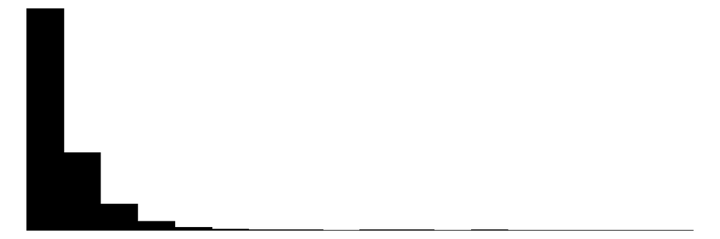

einkommenm2

607

0

11.0

134.0

0.0

0.0

12033.2

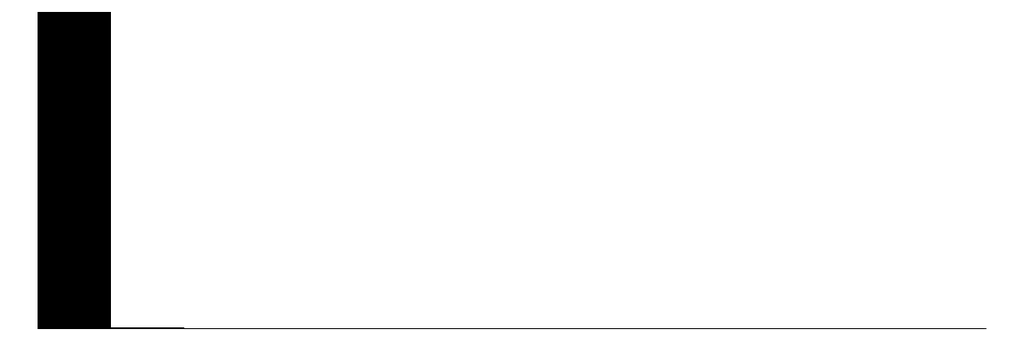

Column names are German, but attribute labels are in English. `einkommenj1` contains *Gross Income from Main Job/Year*.

The documentation (click the DOI https://doi.org/10.5684/soep.practice.v36) tells that there are 6.355 people in the data. Every individual is likely observed multiple times (i.e. panel data). Pipe `soep` into `count()` of personal `id`. The tibble output already contains the number of rows. To literally access the value, ask `nrow()`.

Adding `arrange()` means sorting the data by a variable (i.e. the temporarily created variable `n`) either ascending or descending (from high to low). Ascending is the default. For descending order apply the `desc()` command. `group_by()` is a powerful command, especially when working with panel data. It can do any form of data manipulation or analysis with respect to the chosen variable. At this stage it's a mere alternative `count()`.

```r
# soep %>% group_by(id) %>% count() %>% arrange(n) # try this alternative
soep %>% count(id) %>% arrange(n)
soep %>% count(id) %>% arrange(desc(n))
```

**See result.**

```
#> # A tibble: 6,355 × 2
#>       id     n
#>    <dbl> <int>
#>  1    96     1
#>  2   137     1
#>  3   147     1
#>  4   183     1
#>  5   189     1
#>  6   229     1
#>  7   368     1
#>  8   371     1
#>  9   384     1
#> 10   443     1
#> # ℹ 6,345 more rows
```

Remember that the observation period is between 2015 and 2019, i.e. the minimum number of observations per individual is 1 year, the maximum is 5 years. Over the years, observations get less and less (panel attrition).

```r
table(soep$syear)
```

```
#>
#> 2015 2016 2017 2018 2019
#> 5527 4987 4720 4351 3937
```

How many people are observed in all years? Filter for a specific `n` and ask for the number of rows or observations (alternatively you can check the tibble size again).

`erwerb` is the employment status in SOEP. Its labels range from -7 to 6. Use the `attributes()` command on a specific variable. It returns a set of information (object class is `list`). We can access elements of this list by the `$` operator. Did you notice the small mistake in the labels? (Remember this is practice data.)

```r
attributes(soep$erwerb)$labels
```

**See result.**

```
#>         [-7] Only available in less restricted edition
#>                                                     -7
#>  [-6] Version of questionnaire with modified filtering
#>                                                     -6
#> [-5] Not included in this version of the questionnaire
#>                                                     -5
#>                    [-4] Inadmissable multiple response
#>                                                     -4
#>                                         [-3] not valid
#>                                                     -3
#>                                    [-2] does not apply
#>                                                     -2
#>                                         [-1] no answer
#>                                                     -1
#>                                [-1] Employed full-time
#>                                                      1
#>                                [-2] Employed part-time
#>                                                      2
#>                           [3] Training, apprenticeship
#>                                                      3
#>                [4] Irregular employment or in marginal
#>                                                      4
#>                                       [5] Not employed
#>                                                      5
#>                         [6] Garage for disabled people
#>                                                      6
```

Negative values indicate several different forms of missing data in SOEP.[^25] Actually, there are no negative values in this dataset. As for levels of a factor variables, labels can be empty.

```r
table(soep$erwerb)
```

```
#>
#>    1    2    3    4    5    6
#> 8700 3481  695 1446 9169   29
```